# abramov-etal-2017

Rick Gilmore & Yiming Qian

2019-10-03 08:00:28

# Sex differences in vision

## Discussion of (Abramov, Gordon, Feldman, & Chavarga, 2012)

Abramov, I., Gordon, J., Feldman, O., & Chavarga, A. (2012). Sex & vision I: Spatio-temporal resolution. *Biology of Sex Differences*, *3*(1), 20. bsd.biomedcentral.com. Retrieved from http://dx.doi.org/10.1186/2042-6410-3-20

# What did they do?

## Who were the participants?

- Adults (faculty, graduate and undergraduate students at Brooklyn College, some high school students)
- $n=36$ females (16-38 years; mean = 23.5 years); $n=16$ males (16-37 years; mean 24.3 years)

> “*These numbers of participants are appreciably larger than those in the vast majority of detailed psychophysical studies of vision.*”

## What tasks did they perform?

### Primary

- *Spatio-Temporal Contrast Sensitivity Function (ST-CSF)*

#### Contrast sensitivity function example

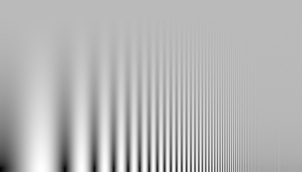

https://understandinglowvision.com/2-0-contrast-sensitivity-function/

### Secondary

- *Stereopsis* or binocular depth perception ([Titmus Fly Book Test](https://www.stereooptical.com/wp-content/uploads/2018/01/LEA-symbols-FLY-2017-User-manual-ONLY-12212017-2.pdf); [Randot Stereo Acuity Test](https://www.stereooptical.com/products/stereotests-color-tests/randot/); [TNO anaglypic random-dot plates](https://en.wikipedia.org/wiki/Random_dot_stereogram))
- Color perception
- Acuity

## What specific variables/measures were of interest?

> *I* manipulate *independent variables* (controlled variables or ‘inputs’); ‘*D*ey’ provide information about dependent variables (responses/outcome variables or ‘outputs’)
- *ST-CSF thresholds*
  - at different *spatial frequencies* and *temporal frequencies*

## How many visits/data collection sessions?

- 15+ laboratory sessions

> “*Furthermore, each of our participants had to complete our entire Battery of tests of vision; this entailed coming to the laboratory for fifteen or more sessions of approximately one hour.*”

## How were the data analyzed?

# What did they find?

## Group contrast sensitivity functions (females)

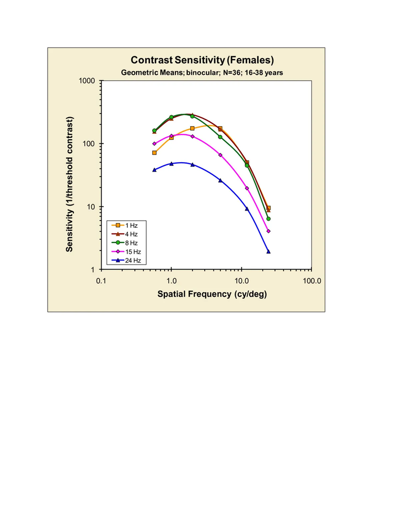

[Abramov et al. 2012, Figure 1](https://bsd.biomedcentral.com/articles/10.1186/2042-6410-3-20/figures/1)

## Group contrast sensitivity functions (males)

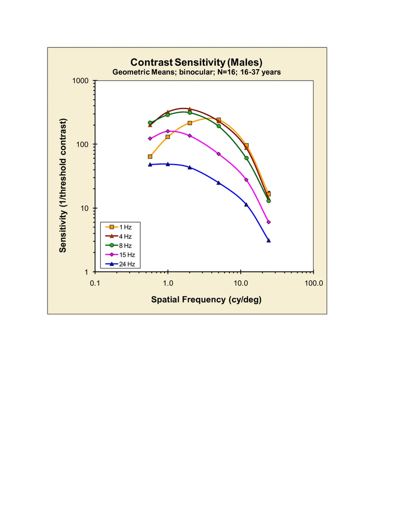

[Abramov et al. 2012, Figure 1](https://bsd.biomedcentral.com/articles/10.1186/2042-6410-3-20/figures/2)

## Ratios of group contrast sensitivity functions (Males/Females)

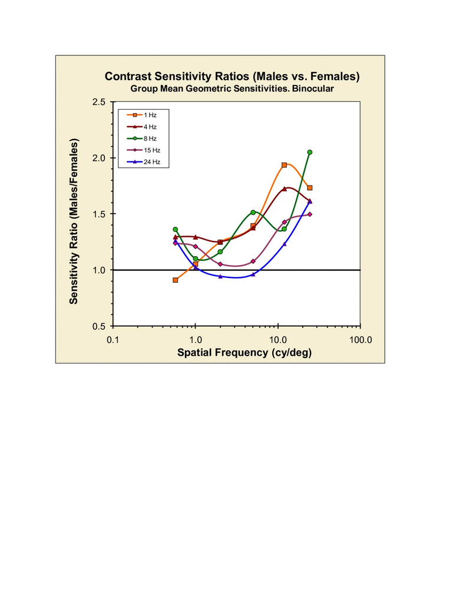

[Abramov et al. 2012, Figure 1](https://bsd.biomedcentral.com/articles/10.1186/2042-6410-3-20/figures/3)

# Questions and constructive comments

# References

Abramov, I., Gordon, J., Feldman, O., & Chavarga, A. (2012). Sex & vision i: Spatio-temporal resolution. *Biology of Sex Differences*, *3*(1), 20. https://doi.org/10.1186/2042-6410-3-20